# Chapter 5 of MHE: Fixed Effects, Diff-in-Diff and Panel Data

07 September, 2018

### (MHE) Section 5.2.1 - Regression Differnce in Difference

We want to reproduce Figure 5.2.4 from MHE. This figure was originally produced by [Autor (2003)](http://economics.mit.edu/files/589) (Figure 3 in the original) to show the estimated impact of a law (implied-contract exceptions to the employment-at-will doctrine) over an outcome (the use of temporary workers).

## Download and load the data

First download the data from the author’s website (will migrate to external data repo in the future!), and load it in to R.

```r
# Download the data and unzip it
download.file('http://economics.mit.edu/~dautor/outsourcingatwill_table7.zip',
              'outsourcingatwill_table7.zip')
unzip('outsourcingatwill_table7.zip')
```

```r
# Load the data
autor <- read.dta('table7/autor-jole-2003.dta')
```

The data downloaded data set contains 24 years (from 74 to 97) and 50 states, for a total of 1200 observations.

## “Clean” the data

Restrict sample to years between 1979 and 1995 (inclusive), and deleting Guam from the sample (state = 98).

```r
# Restrict sample
autor <- autor[which(autor$year >= 79 & autor$year <= 95), ]
autor <- autor[which(autor$state != 98), ]
```

The clean data now contains 17 years (from 79 to 95) and 50 states, for a total of 850 observations.

## “Build” analytic file

In addition to the variables already defined in the data, we need to construct the following variables:  
- Log of total employment  
- Normalize the year variable to 1978

```r
# Log total employment: from BLS employment & earnings
autor$lnemp <- log(autor$annemp)

# Normalize year to 1978
autor$t  <- autor$year - 78

# Create state and year factors (required format for fe reg package)
autor$state <- factor(autor$state)
autor$year  <- factor(autor$year)
```

## Define model to estimate

We want to estimate a fixed effect model with lead and lag treatment variables:
$$\begin{align}
y_{st} = \gamma_{0s} + \gamma_{1s} t + \lambda_{t} + \sum_{\tau = 0}^{m} \delta_{-\tau} D_{s, t - \tau} +
\sum_{\tau = 1}^{q} \delta_{+\tau} D_{s, t + \tau} + X'_{st} \beta + \varepsilon_{st}
\end{align}$$

Where:  
- $y_{st}$ is the (log) number of jobs under the catergory of Temporary Help Services for each state.  
- $\gamma_{0s}$ are the state fixed effect, $\lambda_{t}$ are the time fixed effec, and $\gamma_{1s} t$ are state specific time trends.  
- $X'_{st}$ contains: log state nonfarm employment, and leads and lags of adoption of the public policy and good faith exceptions.  
- Treatment variables in contemporary ($\delta D_{s, t}$) leads $\delta_{+\tau} D_{s, t + \tau}$ and lags $\delta_{+\tau} D_{s, t + \tau}$

The estimation of this model is presented in column 2 of table 7 of the original paper.

```r
# Diff-in-diff regression
did <- felm(lnths ~ lnemp   + admico_2 + admico_1 + admico0  + admico1  + admico2 +
                    admico3 + mico4    + admppa_2 + admppa_1 + admppa0  + admppa1 +
                    admppa2 + admppa3  + mppa4    + admgfa_2 + admgfa_1 + admgfa0 +
                    admgfa1 + admgfa2  + admgfa3  + mgfa4
                    | state + year + state:t | 0 | state, data = autor)
```

## Vizualize the results

And this estimates are then used to create figure 3 of the original paper, which is figure 5.2.4 in MHE.

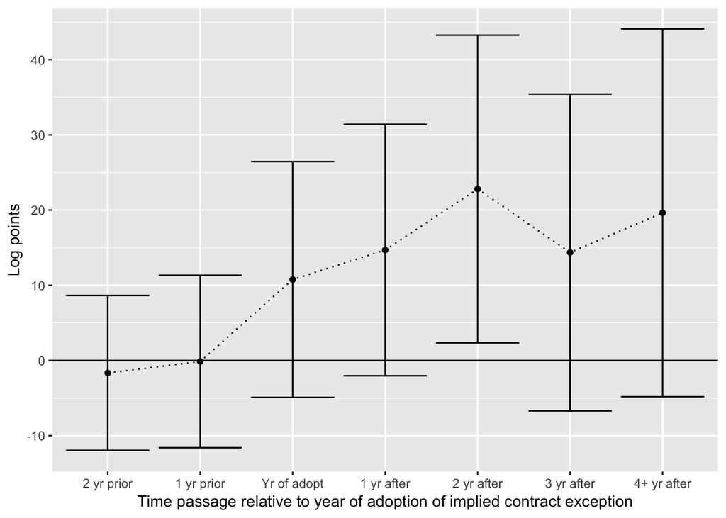

```r
# Plot results
lags_leads  <- c("admico_2", "admico_1", "admico0",
                 "admico1" , "admico2" , "admico3",
                 "mico4")
labels      <- c("2 yr prior", "1 yr prior", "Yr of adopt",
                 "1 yr after", "2 yr after", "3 yr after",
                 "4+ yr after")
results.did <- data.frame(label = factor(labels, levels = labels),
                          coef  = summary(did)$coef[lags_leads, "Estimate"] * 100,
                          se    = summary(did)$coef[lags_leads, "Cluster s.e."] * 100)
g           <- ggplot(results.did, aes(label, coef, group = 1))
p           <- g + geom_point()                                +
                   geom_line(linetype = "dotted")              +
                   geom_errorbar(aes(ymax = coef + 1.96 * se,
                                     ymin = coef - 1.96 * se)) +
                   geom_hline(yintercept = 0)                  +
                   ylab("Log points")                          +
                   xlab(paste("Time passage relative to year of",
                              "adoption of implied contract exception"))
print(p)
```

```r
ggsave(p, file = "Figure 5-2-4-R.png", height = 6, width = 8, dpi = 300)

# End of script
```